# Сравнение линейных моделей

## Мы рассмотрим

- Принципы выбора лучшей линейной модели
- Сравнение линейных моделей
- Сравнение предсказательной силы линейных моделей с использованием кросс-валидации

### Вы сможете

- Объяснить связь между качеством описания существующих данных и краткостью модели
- Объяснить, что такое "переобучение" модели
- Рассказать, каким образом происходит кросс-валидация моделей
- Протестировать влияние отдельных параметров линейной регрессии при помощи сравнения вложенных моделей
- Оценить предсказательную силу модели при помощи k-кратной кросс-валидации

## Принципы выбора лучшей линейной модели

"Essentially, all models are wrong,  
but some are useful"  
Georg E. P. Box

## Два подхода к исследованию: Тестирование гипотезы VS Построение модели

При тестировании гипотезы, если нулевая гипотеза отвергнута, мы лишь утверждаем, что наши данные не противоречат некоторой постулированной закономернсти (*"концептуальной модели"*)

## Два подхода к исследованию: Тестирование гипотезы VS Построение модели

При построении модели мы ставим более широкую задачу.

1. Проверка соответствия наблюдаемых данных предполагаемой функциональной связи между зависимой перменной и предикторами: оценки параметров, проверка их статистической значимости, \(R^2\), анализ остатков.
2. Разработка инструмента для предсказания значений в новых условиях: оценка предсказательной способности.

## Проблема переобученности моделей (overfitting)

## Все ли хорошо с подобранной моделью?

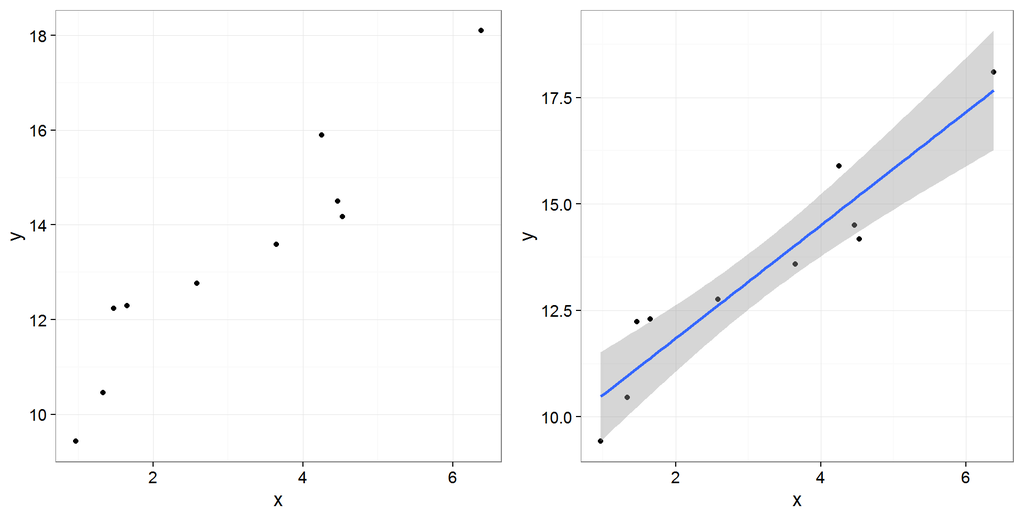

## Для этих данных можно подобрать несколько моделей

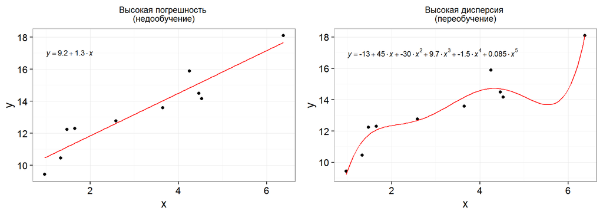

В недообученной (underfitted) модели слишком мало параметров, ее предсказания неточны.

В переобученной (overfitted) модели слишком много параметров, она предсказывает еще и случайный шум.

## Оптимальная модель

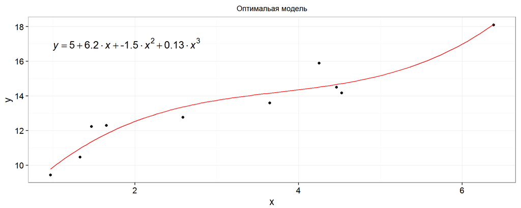

## Последствия переобучения модели

Переобучение происходит, когда модель из-за избыточного усложнения описывает уже не только отношения между переменными, но и случайный шум

При увеличении числа предикторов в модели:  
- более точное описание данных, по которым подобрана модель  
- низкая точность предсказаний на новых данных из-за переобучения.

## При постоении моделей важно помнить о трех типах дисперсии

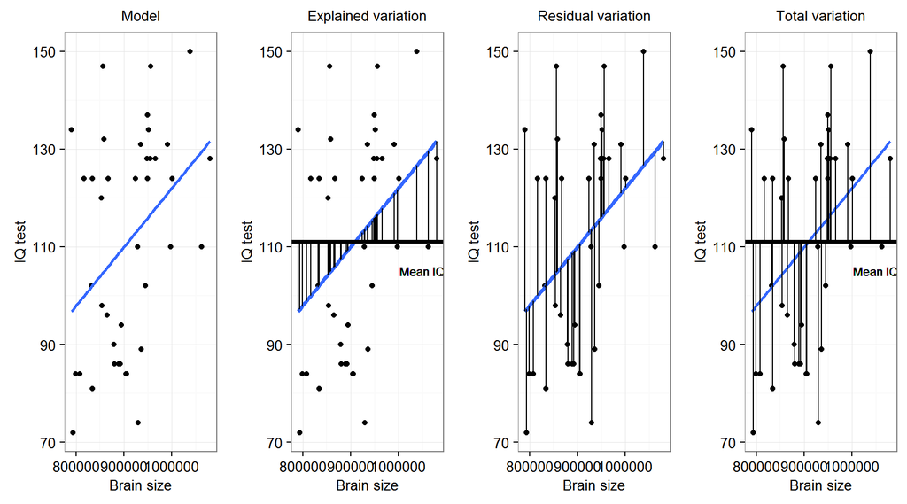

## При постоении моделей важно помнить о трех типах дисперсии

| **Объясненная дисперсия** | **Остаточная дисперсия** | **Полная дисперсия** |
| --- | --- | --- |
| \(SS_{Regression}=\sum{(\hat{y}-\bar{y})^2}\) | \(SS_{Residual}=\sum{(\hat{y}-y_i)^2}\) | \(SS_{Total}=\sum{(\bar{y}-y_i)^2}\) |
| \(df_{Regression} = 1\) | \(df_{Residual} = n-2\) | \(df_{Total} = n-1\) |
| \(MS_{Regression} =\frac{SS_{Regression}}{df}\) | \(MS_{Residual} =\frac{SS_{Residual}}{df_{Residual}}\) | \(MS_{Total} =\frac{SS_{Total}}{df_{Total}}\) |

## Компромисс при подборе оптимальной модели: точность vs. описание шума

### Хорошее описание существующих данных

Если мы включим много переменных, то лучше опишем данные: большая объясненная изменчивость (\(R^2\)), маленькая остаточная изменчивость (\(MS_{Residual}\))

Но стандартные ошибки параметров будут большие, интерпретация сложная

### Принцип парсимонии

*Entia non sunt multiplicanda praeter necessitatem*

Минимальный набор переменных, который может объяснить существующие данные

Стандартные ошибки параметров будут ниже, интерпретация проще

## Критерии и методы выбора моделей зависят от задачи

### Задачи 1 типа: *Объяснение закономерностей*

- Нужны точные тесты влияния предикторов: F-тесты или тесты отношения правдоподобий (likelihood-ratio tests)

### Задачи 2 типа: *Описание функциональной зависимости*

- Нужна точность оценки параметров и парсимония: "информационные" критерии (АIC, BIC, AICc, QAIC, и т.д.)

### Задачи 3 типа: *Предсказание значений зависимой переменной*

- Нужна оценка качества модели на данных, которые не использовались для ее первоначальной подгонки: методы ресамплинга (кросс-валидация, бутстреп)

## Дополнительные критерии для сравнения моделей:

### Не позволяйте компьютеру думать за вас!

- *Хорошая модель должна соответствовать условиям применимости*: анализ остатков, проверк на наличие автокорреляций, выбросы, наличие мультиколлинеарности предикторов и проч.
- *Другие соображения*: разумность, целесообразность модели, простота, ценность выводов, важность предикторов.

## Сравнение линейных моделей

## Вложенные модели (nested models)

Две модели являются *вложенными*, если одну из них можно получить из другой путем удаления некоторых предикторов.

Удаление предиктора - коэффициент при данном предикторе равен нулю.

### Полная модель (full model)

М1: \(y _i = \beta _0 + \beta _1 x _1 + \beta _2 x _2 + \epsilon _i\)

### Неполные модели (reduced models)

М2: \(y _i = \beta _0 + \beta _1 x _1 + \epsilon _i\)

М3: \(y _i = \beta _0 + \beta _2 x _2 + \epsilon _i\)

M2 вложена в M1  
M3 вложена в M1  
M2 и M3 не вложены друг в друга

### Нулевая модель (null model), вложена в полную (M1) и в неполные (M2, M3)

\(y _i = \beta _0 + \epsilon _i\)

## Для тренировки запишем вложенные модели для данной полной модели

(1)\(y _i = \beta _0 + \beta _1 x _1 + \beta _2 x _2 + \beta _3 x _3 + \epsilon _i\)

Модели:

- (2)\(y _i = \beta _0 + \beta _1 x _1 + \beta _2 x _2 + \epsilon _i\)
- (3)\(y _i = \beta _0 + \beta _1 x _1 + \beta _3 x _3 + \epsilon _i\)
- (4)\(y _i = \beta _0 + \beta _2 x _2 + \beta _3 x _3 + \epsilon _i\)
- (5)\(y _i = \beta _0 + \beta _1 x _1 + \epsilon _i\)
- (6)\(y _i = \beta _0 + \beta _2 x _2 + \epsilon _i\)
- (7)\(y _i = \beta _0 + \beta _3 x _3 + \epsilon _i\)
- (8)\(y _i = \beta _0 + \epsilon _i\)

Вложенность:

- (2)-(4)- вложены в (1)
- (5)-(7)- вложены в (1), при этом
- (5)вложена в (1), (2), (3);
- (6)вложена в (1), (2), (4);
- (7)вложена в (1), (3), (4)
- (8)- нулевая модель - вложена во все

## Сравнение вложенных линейных моделей при помощи F-критерия

### Полная модель

\(y _i = \beta _0 + \beta _1 x _{i1} + ... + \beta _k x _{ik} + ... + \beta _p x _{ip} + \epsilon _i\)  
\(df _{reduced, full} = p\)  
\(df _{error, full} = n - p - 1\)

### Уменьшеная модель

\(y _i = \beta _0 + \beta _1 x _{i1} + ... + \beta _k x _{ik} + \epsilon _i\)  
\(df _{reduced, reduced} = k\)  
\(df _{error, reduced} = n - k - 1\)

### Частный F-критерий - оценивает выигрыш объясненной дисперсии от включения фактора в модель

\[F = \frac {(SS _{error,reduced} - SS _{error,full}) / (df _{reduced, full} - df _{reduced, reduced})} {(SS _{error, full})/ df _{error, full}}\]

## Сравнение линейных моделей при помощи частного F-критерия

Модели обязательно должны быть вложенными!

### Обратный пошаговый алгоритм (backward selection)

1. Подбираем полную модель
2. Строим редуцированную модель (лишенную одного из предикторов) вложенную в исходную полную модель
3. Тестируем отличие редуцированой модели от полной модели
4. Предиктор, удаление которого **не ухудшает** модель, выкидываем из рассмотреия и принимаем редуцированную модель, как "родительскую" для следующего раунда упрощения.

Повторяем 2-4 до тех пор, пока что-то можно удалить.

**Важно!** Если модель содержит взаимодействия между предикторами, то в первую очередь надо посмотреть можно ли от него избавиться. Если взаимодействие из модели удалить нельзя, то нельзя удалять и основные члены модели, входящие во взаимодействие.

## Пример: птицы в лесах Австралии

От каких характеристик лесного участка зависит обилие птиц в лесах юго-западной Виктории, Австралия (Loyn, 1987)

Переменных много, мы хотим из них выбрать **оптимальный небольшой** набор.

56 лесных участков:

- ABUND - обилие птиц
- AREA - площадь участка
- YRISOL - год изоляции участка
- DIST - расстояние до ближайшего леса
- LDIST - расстояние до ближайшего большого леса
- GRAZE - пастбищная нагрузка (1-5)
- ALT - высота над уровнем моря

## Вспомним, что мы знаем про эту модель с прошлого раза

```r
birds <- read.csv("data/loyn.csv")
M <- lm(ABUND ~ ., data = birds)
library(car)
vif(M) # есть колинеарные предикторы
```

```
##   AREA YRISOL   DIST  LDIST  GRAZE    ALT
##   1.34   1.84   1.23   1.26   2.31   1.57
```

```r
# GRAZE - избыточный предиктор, удаляем
M1 <- update(M, .~. - GRAZE)
vif(M1)
```

```
##   AREA YRISOL   DIST  LDIST    ALT
##   1.25   1.10   1.16   1.24   1.43
```

## .

Незначимо влияние AREA, DIST, LDIST

```r
summary(M1)
```

```
##
## Call:
## lm(formula = ABUND ~ AREA + YRISOL + DIST + LDIST + ALT, data = birds)
##
## Residuals:
##     Min      1Q  Median      3Q     Max
## -15.636  -5.211  -0.277   4.735  22.963
##
## Coefficients:
##               Estimate Std. Error t value Pr(>|t|)
## (Intercept) -344.79073   91.61744   -3.76  0.00044 ***
## AREA           0.00459    0.00488    0.94  0.35132
## YRISOL         0.17928    0.04760    3.77  0.00044 ***
## DIST           0.00772    0.00571    1.35  0.18233
## LDIST          0.00192    0.00141    1.36  0.17978
## ALT            0.07638    0.03195    2.39  0.02062 *
## ---
## Signif. codes:  0 '***' 0.001 '**' 0.01 '*' 0.05 '.' 0.1 ' ' 1
##
## Residual standard error: 8.61 on 50 degrees of freedom
## Multiple R-squared:  0.415,  Adjusted R-squared:  0.357
## F-statistic:  7.1 on 5 and 50 DF,  p-value: 0.000044
```

## Частный F-критерий, 1 способ: `anova(модель_1, модель_2)`

Вручную выполняем все действия

```r
M2 <- update(M1, . ~ . - AREA)
anova(M1, M2)
```

```
## Analysis of Variance Table
##
## Model 1: ABUND ~ AREA + YRISOL + DIST + LDIST + ALT
## Model 2: ABUND ~ YRISOL + DIST + LDIST + ALT
##   Res.Df  RSS Df Sum of Sq    F Pr(>F)
## 1     50 3707
## 2     51 3772 -1     -65.6 0.89   0.35
```

## Частный F-критерий, 2 способ: `drop1()`

Вручную тестировать каждый предиктор с помощью `anova()` слишком долго. Можно протестировать все за один раз при помощи `drop1()`

```r
drop1(M1, test = "F")
```

```
## Single term deletions
##
## Model:
## ABUND ~ AREA + YRISOL + DIST + LDIST + ALT
##        Df Sum of Sq  RSS AIC F value  Pr(>F)
## <none>              3707 247
## AREA    1        66 3772 246    0.89 0.35132
## YRISOL  1      1052 4759 259   14.19 0.00044 ***
## DIST    1       136 3842 247    1.83 0.18233
## LDIST   1       137 3844 247    1.85 0.17978
## ALT     1       424 4130 251    5.72 0.02062 *
## ---
## Signif. codes:  0 '***' 0.001 '**' 0.01 '*' 0.05 '.' 0.1 ' ' 1
```

```r
# Нужно убрать AREA
```

## .

```r
# Убрали AREA
M2 <- update(M1, . ~ . - AREA)
drop1(M2, test = "F")
```

```
## Single term deletions
##
## Model:
## ABUND ~ YRISOL + DIST + LDIST + ALT
##        Df Sum of Sq  RSS AIC F value  Pr(>F)
## <none>              3772 246
## YRISOL  1      1004 4776 257   13.57 0.00056 ***
## DIST    1       166 3938 246    2.24 0.14027
## LDIST   1       165 3937 246    2.23 0.14150
## ALT     1       719 4491 254    9.72 0.00300 **
## ---
## Signif. codes:  0 '***' 0.001 '**' 0.01 '*' 0.05 '.' 0.1 ' ' 1
```

```r
# Нужно убрать LDIST
```

## .

```r
# Убрали LDIST
M3 <- update(M2, . ~ . - LDIST)
drop1(M3, test = "F")
```

```
## Single term deletions
##
## Model:
## ABUND ~ YRISOL + DIST + ALT
##        Df Sum of Sq  RSS AIC F value Pr(>F)
## <none>              3937 246
## YRISOL  1       959 4896 256   12.67 0.0008 ***
## DIST    1       311 4248 248    4.11 0.0478 *
## ALT     1       589 4526 252    7.78 0.0074 **
## ---
## Signif. codes:  0 '***' 0.001 '**' 0.01 '*' 0.05 '.' 0.1 ' ' 1
```

```r
# Больше ничего убрать не получается
```

## Итоговая модель

```r
summary(M3)
```

```
##
## Call:
## lm(formula = ABUND ~ YRISOL + DIST + ALT, data = birds)
##
## Residuals:
##    Min     1Q Median     3Q    Max
## -16.60  -5.75   0.57   5.08  23.72
##
## Coefficients:
##               Estimate Std. Error t value Pr(>|t|)
## (Intercept) -325.25283   91.81925   -3.54  0.00085 ***
## YRISOL         0.16961    0.04766    3.56  0.00080 ***
## DIST           0.01103    0.00544    2.03  0.04784 *
## ALT            0.07807    0.02800    2.79  0.00738 **
## ---
## Signif. codes:  0 '***' 0.001 '**' 0.01 '*' 0.05 '.' 0.1 ' ' 1
##
## Residual standard error: 8.7 on 52 degrees of freedom
## Multiple R-squared:  0.379,  Adjusted R-squared:  0.343
## F-statistic: 10.6 on 3 and 52 DF,  p-value: 0.0000156
```

## Тесты отношения правдоподобий

## Ограничение частного F-критерия

Частный F-критерий применим только для сравнения двух вложенных моделей, подобранных *методом наименьших квадатов*.

Этот метод не применим для более сложных моделей.  
Для подбора более сложных моделй используется *метод максимального правдоподобия*.

## Правдоподобие

Правдоподобие (likelihood) - это соотверствие имеющихся данных тому, что можно получить при определенных значениях параметров модели.

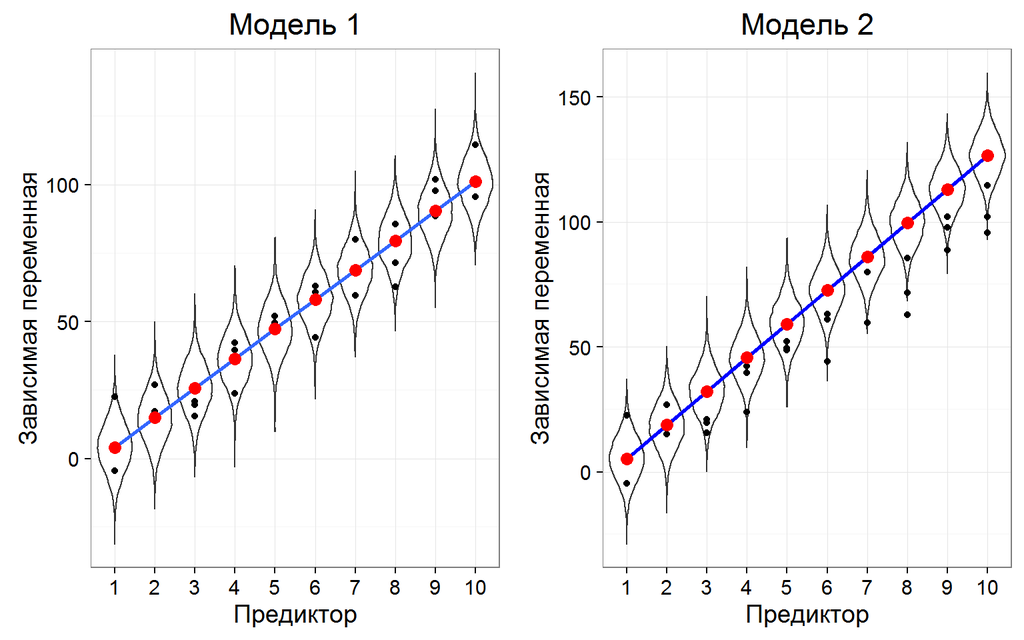

## Правдоподобие

Чтобы измерить правдоподобие нам нужно оценить вероятность получения имеющегося набора значений зависимой переменной при заданных параметрах модели, описывающей связь между зависимой переменной и предикторами.

Мы оцениваем это как произведение вероятностей получения каждой из точек данных

\(L(x_1, ..., x_n) = \Pi^n _{i = 1}f(x_i; \theta)\)

где \(f(x; \theta)\) - функция плотности распределения с параметрами \(\theta\)

## Выводим формулу правдоподобия для линейной модели с нормальным распределением ошибок

Пусть в нашей модели остатки нормально распределены (\(\epsilon_i \sim N(0, \sigma^2)\)) и их значения независимы друг от друга:

\(N(\epsilon_i; 0, \sigma^2) = \frac {1} { \sqrt {2\pi\sigma^2} } exp (-\frac {1} {2 \sigma^2} \epsilon^2)\)

Тогда можно описать вероятность получения нашего набора данных при помощи функции правдоподобия (likelihood), как произведение вероятностей:

\(L = \Pi^n _{n = 1} N(\epsilon, \sigma^2) = (\frac {1} {2\pi\sigma^2})^{n/2} exp(- \frac {1} {2\sigma^2} \sum \epsilon^2_i)\)

\(\epsilon = y_i - \hat y_i\)

## Подбор параметров модели

В случае регрессии от одной переменной (для простоты)

\(\hat y_i = b_0 + b_1 x\)

Реализуется алгоритм поиска такого сочетания \(b_0\), \(b_1\) и \(\sigma\), при котором \(L = \Pi^n _{n = 1} N(\epsilon, \sigma^2)\) (функция правдоподобия) будет иметь максимум.

## Логарифм правдоподобия

Вычислительно проще работать с логарифмами правдоподобий (loglikelihood)

\[logLik (\beta, \sigma) = - \frac{n}{2} ln(2\pi) - \frac{n}{2} ln(\sigma^2) - \frac{1}{2\sigma^2}(\sum \epsilon^2_i)\]

\(\beta\) - вектор параметров модели \(\sigma\) - дисперсия остатков

Чем больше логарифм правдоподобия тем лучше модель.

## Подбор параметров модели методом максимального правдоподобия

Для подбора параметров методом максимального правдоподобия используют функцию `glm()` и ряд других, более специализированных, функций.

```r
# Создаем симулированные данные
xy <- data.frame(X = rep(1:10, 3))
xy$Y <- 10*xy$X + rnorm(30, 0, 10)

# Подбираем модель
Mod <- lm(Y ~ X, data = xy)
Mod_glm <- glm(Y ~ X, data = xy)

coefficients(Mod)
```

```
## (Intercept)           X
##      -0.419      10.318
```

```r
coefficients(Mod_glm)
```

```
## (Intercept)           X
##      -0.419      10.318
```

## Логарифм правдоподобия

\(LogLik\) для модели можно найти с помощью функции `logLic()`

```r
logLik(Mod_glm)
```

```
## 'log Lik.' -111 (df=3)
```

## Логарифм правдоподобия вручную

```r
xy$predicted <- predict(Mod) # Предсказанные моделью значения

SD <- summary(Mod)$sigma # Оценка дисперсии

xy$Prob <- dnorm(xy$Y, mean = xy$predicted, sd = SD) # Вероятности для каждой точки

xy$LogProb <- log(xy$Prob) # Логарифм вероятностей

sum(xy$LogProb) # Логарифм произведения, равный сумме логарифмов
```

```
## [1] -111
```

## Тест отношения правдоподобий (Likelihood Ratio Test)

Тест отношения правдоподобий позволяет определить какая модель более правдоподобна с учетом данных.

\(LRT = 2ln(L_1/L_2) = 2(logL_1 - logL_2)\)

- \(L_1\), \(L_2\) - правдоподобия полной и уменьшеной модели
- \(logL_1\), \(logL_2\) - логарифмы правдоподобий

Разница логарифмов правдоподобий имеет распределение \(\chi^2\) с числом степеней свободы \(df = df_2 - df_1\)